# Proj01_1_35_벤처

강효진, 황낙주

2018년 11월 2일

#### 1. 데이터 설명

- 데이터에 흥미를 가지게 된 이유
  - 4차 산업혁명 시대가 도래하면서, 세계의 많은 국가에서 인공지능 및 빅데이터와 관련된 신규 산업 발달에 도움이 되는 스타트업을 많이 지원하고 있다. 우리나라 또한 이전 정권부터 스타트업을 지원하는 ’중소벤처기업부’가 생겨났다. 이러한 상황에서 지금까지의 벤처기업 현황을 알아보고자 한다.
  - 데이터 내에서 기업의 가장 중요한 요소라고 할 수 있는 자산과, 창업자의 학력 및 전공 간의 관계를 알아보고자 한다. 추가적으로 많은 대학생들이 스타트업에 관심을 갖고 있고, 창업을 준비하는 경우도 많은데, 학력과 자본이 어떻게 연결될 수 있는지 궁금증을 갖게 되었다.
- 데이터와 관련된 배경이론
  - 유럽 국가들은 ’현금 없는 사회’로 도약을 위해 핀테크 관련 스타트업에 크게 집중하여 지원하고 있다. 우리나라 또한 그러한 스타트업을 지원하는 다양한 정책이 있지만, 우리나라의 핀테크 산업 발달은 유럽 국가들에 비해 저조하다. 그 이유는 다음과 같다.
    1. 경직된 조직문화(상명하복식의 조직문화)
    2. 규제 정책 - 기업에 대한 낮은 신뢰도(기업에 관한 거의 모든 것을 정부에 알려야 함)
    3. 기술적인 인프라 부족(클라우드 시스템, 빅데이터 기술 등)
- 데이터를 통해 알고자 하는 내용 앞서 언급한 것처럼 창업자의 학력 및 전공과 기업의 자본력이 어떻게 연결될 수 있는지 알아보고자 한다.
- 데이터와 관련된 가설
  - 가설 : 창업자의 학력과 기업의 자산 규모는 비례할 것이다.
  - 학력과 자산이 비례하는 경우는 성장 배경에서 부터 경제적 여건이 좋아 학력이 높은 경우와 경제적 여건은 좋지 않지만 높은 학력을 통해 자본을 얻을 수 있는 능력이 생긴 경우로 나눌 수 있다. 그러나, 학력이 낮은 경우, 경제적 여건이 좋은 경우와 좋지 않은 경우 모두 기업의 자본에 긍정적 영향을 미치기 어렵다고 볼 수 있다.

#### 2. 데이터 불러들이기

- 필요한 함수 library

```r
library(dplyr)
library(ggplot2)
library(tidyr)
library(gridExtra)
```

1. 데이터 불러오기

```r
startup_raw <- read.csv("2017년_벤처기업정밀실태조사.csv")
startup <- startup_raw #원본 데이터의 손실을 막기 위해 데이터를 다른 이름으로 저장
```

2. 변수명 변경

```r
#변수명의 가독성을 높이기 위해 변수명 변경
startup <- rename(startup,
                  edu_lvl = B2.4..창업.당시.창업주.최종학력,
                  asset = D2.1..2016년.자산.백만원. ,
                  debt = D2.2..2016년.부채.백만원. ,
                  capital = D2.3..2016년.자본.백만원. ,
                  under_master_major = B2.4.1..창업.당시.창업주.전공.대졸.전문학사. ,
                  engineer = B2.4.2..창업.당시.창업주.전공.석사이상....공학 ,
                  nat_sci = B2.4.2..창업.당시.창업주.전공.석사이상....자연과학 ,
                  business = B2.4.2..창업.당시.창업주.전공.석사이상....경영.경제학 ,
                  soci_sci = B2.4.2..창업.당시.창업주.전공.석사이상....인문사회학 ,
                  etc = B2.4.2..창업.당시.창업주.전공.석사이상....기타 ,
                  expr1 = B2.9..창업주.과거.창업.경험.여부,
                  expr_success = B2.9.1..과거.창업.경험.결과.및.횟수.번....성공,
                  expr_fail = B2.9.1..과거.창업.경험.결과.및.횟수.번....실패,
                  expr_total = B2.9.1..과거.창업.경험.결과.및.횟수.번....합계,
                  year = A2.1..창업년도)

#under_master_major의 숫자가 각각 어떤 전공을 나타내는지 알 수 있도록 함
major_dat <- data.frame(under_master_major = c(1, 2, 3, 4, 5),
                        u_master_major = c('engineer', 'nat_sci', 'business', 'soci_sci', 'etc'))
major_dat
```

```
##   under_master_major u_master_major
## 1                  1       engineer
## 2                  2        nat_sci
## 3                  3       business
## 4                  4       soci_sci
## 5                  5            etc
```

```r
startup <- full_join(startup, major_dat)

#학력과 숫자가 비례하도록 역코딩
edu_dat <- data.frame(edu_lvl = c(1,2,3,4,5,6),
                      edu = c(6,5,4,3,2,1))
startup <- full_join(startup, edu_dat)
```

rename한 변수명에 대한 설명을 정리하면 다음과 같다.

- edu_lvl : 창업 당시 창업주의 최종학력
- asset : 기업의 보유 자산
- debt : 기업의 부채
- capital : 기업의 자본
- under_master_major : 대졸자 전공
- engineer : 석사 이상 창업자의 전공이 공학계열임
- nat_sci : 석사 이상 창업자의 전공이 자연과학계열임
- business : 석사 이상 창업자의 전공이 경영 및 경제 계열임
- soci_sci : 석사 이상 창업자의 전공이 사회과학계열임
- etc : 석사 이상 창업자의 전공이 위 4개 항목과 다른 경우임
- expr1 : 창업자의 과거 창업 경험의 유무 확인 (1 또는 2값으로 구분)
- expr_success : 과거 창업에 대한 성공 횟수
- expr_fail : 과거 창업에 대한 실패 횟수
- expr_total : 과거 창업에 대한 전체 횟수
- year : 창업년도

역코딩한 학력의 수준은 다음과 같다.

- 6 : 박사
- 5 : 석사
- 4 : 대졸
- 3 : 전문학사
- 2 : 고졸
- 1 : 중졸
3. 새로운 변수 추가

```r
#창업년도를 이용하여 만들어진 시기별로 분류, 업력을 구함
startup$years <- ifelse(2017 - startup$year <= 3, "3년이하기업",
                        ifelse (2017 - startup$year >= 6, "기성기업", "4_5년기업"))
```

4. 데이터 합치기

```r
#학력 및 경험에 따라 변수를 선택하여 새로운 데이터 생성
startup_edu <- startup %>%
  select(asset, debt, capital, edu, u_master_major, engineer, nat_sci, business, soci_sci, etc)

startup_expr <- startup %>%
  select(asset, debt, capital, expr1, expr_success, expr_fail, expr_total, year, years)

#join을 이용하여 생성한 데이터 병합
startup_tot <- full_join(startup_edu, startup_expr)
```

#### 3. 데이터를 살펴보는 과정

1. 데이터타입 수정

```r
#str 함수를 활용하여 모든 칼럼의 변수타입 확인 후 변수 타입 수정
str(startup_tot)
```

```
## 'data.frame':    2114 obs. of  16 variables:
##  $ asset         : num  57755 1901 4070 1054 741 ...
##  $ debt          : num  28978 1694 1780 640 299 ...
##  $ capital       : Factor w/ 1890 levels "(1045)","(11)",..: 920 659 734 1210 1262 555 102 791 1715 1833 ...
##  $ edu           : num  5 4 5 4 2 4 2 1 4 2 ...
##  $ u_master_major: Factor w/ 5 levels "business","engineer",..: 5 1 4 2 NA 5 NA NA 2 NA ...
##  $ engineer      : int  NA NA NA NA NA NA NA NA NA NA ...
##  $ nat_sci       : int  NA NA 2 NA NA NA NA NA NA NA ...
##  $ business      : int  NA NA NA NA NA NA NA NA NA NA ...
##  $ soci_sci      : int  4 NA NA NA NA NA NA NA NA NA ...
##  $ etc           : int  NA NA NA NA NA NA NA NA NA NA ...
##  $ expr1         : int  2 2 2 2 2 2 2 2 2 1 ...
##  $ expr_success  : int  NA NA NA NA NA NA NA NA NA 1 ...
##  $ expr_fail     : int  NA NA NA NA NA NA NA NA NA 0 ...
##  $ expr_total    : int  NA NA NA NA NA NA NA NA NA 1 ...
##  $ year          : int  2014 2010 2006 2011 2014 2008 2009 2008 2008 1996 ...
##  $ years         : chr  "3년이하기업" "기성기업" "기성기업" "기성기업" ...
```

```r
head(startup_tot$capital) #실제 값 확인
```

```
## [1] 28777  207    2290   414    442    181
## 1890 Levels: (1045) (11) (13419) (13651) (14) (1429) (1608) (163) ... 9991
```

```r
startup_tot$capital <- as.numeric(startup_tot$capital) #factor변수를 numeric으로 수정
startup_tot$expr_success <- as.numeric(startup_tot$expr_success)
startup_tot$expr_fail <- as.numeric(startup_tot$expr_fail)
startup_tot$expr_total <- as.numeric(startup_tot$expr_total)
summary(startup_tot)
```

```
##      asset             debt           capital            edu
##  Min.   :    68   Min.   :    12   Min.   :   1.0   Min.   :1.00
##  1st Qu.:  2339   1st Qu.:  1134   1st Qu.: 474.2   1st Qu.:4.00
##  Median :  6960   Median :  3786   Median : 943.0   Median :4.00
##  Mean   : 17260   Mean   :  9236   Mean   : 945.4   Mean   :4.03
##  3rd Qu.: 18523   3rd Qu.: 10286   3rd Qu.:1418.8   3rd Qu.:5.00
##  Max.   :377190   Max.   :226717   Max.   :1890.0   Max.   :6.00
##
##   u_master_major    engineer       nat_sci        business
##  business: 314   Min.   :1      Min.   :2      Min.   :3
##  engineer:1208   1st Qu.:1      1st Qu.:2      1st Qu.:3
##  etc     :  44   Median :1      Median :2      Median :3
##  nat_sci : 174   Mean   :1      Mean   :2      Mean   :3
##  soci_sci: 105   3rd Qu.:1      3rd Qu.:2      3rd Qu.:3
##  NA's    : 269   Max.   :1      Max.   :2      Max.   :3
##                  NA's   :1749   NA's   :2042   NA's   :2020
##     soci_sci         etc           expr1        expr_success
##  Min.   :4      Min.   :5      Min.   :1.000   Min.   :0.0000
##  1st Qu.:4      1st Qu.:5      1st Qu.:2.000   1st Qu.:1.0000
##  Median :4      Median :5      Median :2.000   Median :1.0000
##  Mean   :4      Mean   :5      Mean   :1.868   Mean   :0.9676
##  3rd Qu.:4      3rd Qu.:5      3rd Qu.:2.000   3rd Qu.:1.0000
##  Max.   :4      Max.   :5      Max.   :2.000   Max.   :9.0000
##  NA's   :2090   NA's   :2104                   NA's   :1836
##    expr_fail        expr_total          year         years
##  Min.   :0.0000   Min.   : 1.000   Min.   :1959   Length:2114
##  1st Qu.:0.0000   1st Qu.: 1.000   1st Qu.:2000   Class :character
##  Median :0.0000   Median : 1.000   Median :2005   Mode  :character
##  Mean   :0.3741   Mean   : 1.342   Mean   :2004
##  3rd Qu.:1.0000   3rd Qu.: 1.000   3rd Qu.:2010
##  Max.   :3.0000   Max.   :10.000   Max.   :2016
##  NA's   :1836     NA's   :1836
```

2. 함수를 이용한 분석

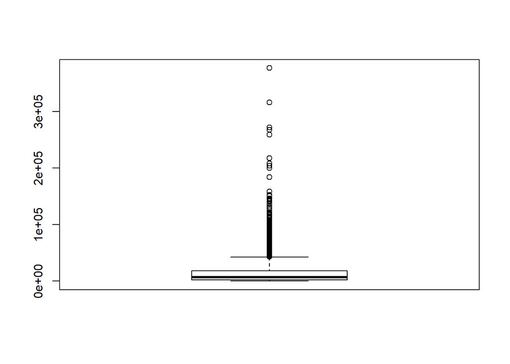

```
##       [,1]
## [1,]    68
## [2,]  2339
## [3,]  6960
## [4,] 18528
## [5,] 42756
```

```r
#자산의 outlier를 boxplot으로 확인
boxplot(startup_tot$asset)
boxplot(startup_tot$asset)$stats
```

- 창업자의 최종학력과 기업 자산 간의 관계

```r
graph1 <- startup_tot %>%
  group_by(edu) %>%
  summarise(mean_asset = mean(asset))
graph1
```

```
## # A tibble: 6 x 2
##     edu mean_asset
##   <dbl>      <dbl>
## 1     1      8998.
## 2     2     13050.
## 3     3     12307.
## 4     4     18087.
## 5     5     16563.
## 6     6     23386.
```

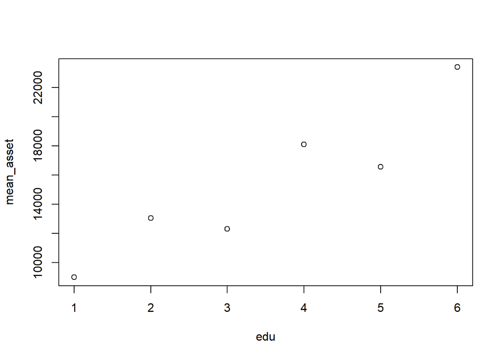

```r
plot(mean_asset ~ edu, data=graph1) #간단한 2변수 시각화
```

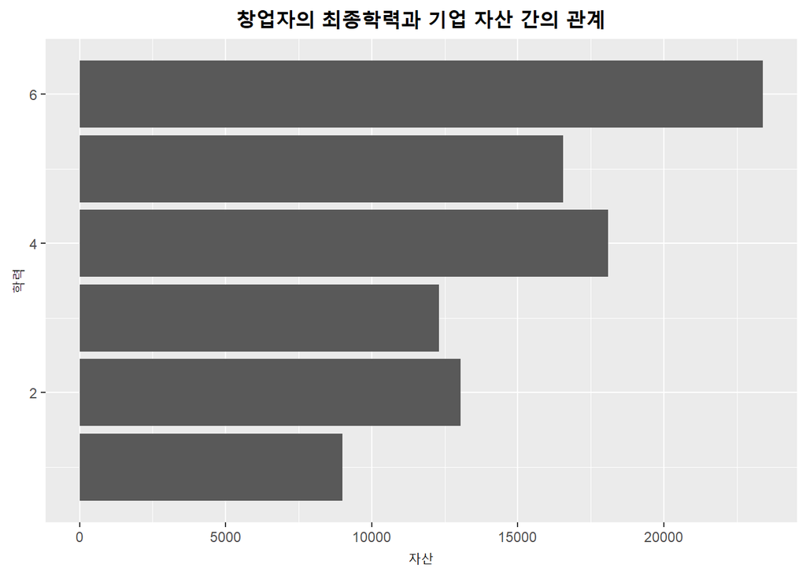

```r
ggplot(graph1, aes(x= edu, y= mean_asset)) +
  geom_col() +
  coord_flip() +
  ggtitle("창업자의 최종학력과 기업 자산 간의 관계") +
  theme(plot.title = element_text(family="NanumGothic", face="bold",size=15, hjust = 0.5)) +
  xlab('학력') +
  ylab('자산') #ggplot을 활용한 시각화
```

전반적인 형태를 보았을 때 중간중간 미세하게 역전이 발생하는 부분을 제외하면, 창업자의 학력과 자산이 일반적으로 비례하는 모습이 나타나는 것을 확인할 수 있다.

[추가] 2가지 그래프에 대한 설명 위의 두 그래프는 같은 값을 나타내고 있는 그래프이다. 그러나 데이터를 전달하는 데 있어서 다른 모습을 보이고 있음을 알 수 있다. 위와 같이, 수치들이 연결되지 않은 데이터의 경우, 아래와 같은 모습으로 표현하는 것이 데이터의 내용을 정확하게 전달하는 데에 도움이 된다는 것을 알 수 있다.

- 창업자의 전공과 기업 자산 간의 관계

```r
#1. 대졸 및 전문학사 과정에서 전공과 기업 자산 간의 관계
graph2 <- startup_tot %>%
  filter(!is.na(u_master_major)) %>%
  group_by(u_master_major) %>%
  summarise(mean_asset = mean(asset))
graph2
```

```
## # A tibble: 5 x 2
##   u_master_major mean_asset
##   <fct>               <dbl>
## 1 business           18220.
## 2 engineer           17851.
## 3 etc                11316
## 4 nat_sci            21472.
## 5 soci_sci           14197.
```

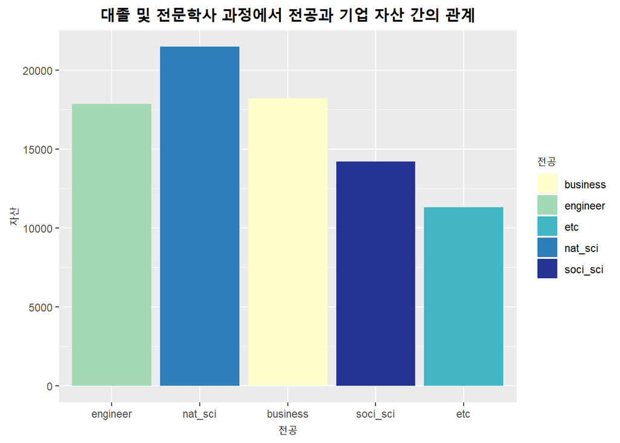

```r
g1 <- ggplot(data = graph2, aes(x = u_master_major, y = mean_asset, fill = u_master_major)) +
  geom_col() +
  scale_fill_brewer(palette = 'YlGnBu') +
  scale_x_discrete(limits = c("engineer", "nat_sci", "business", "soci_sci", "etc")) +
  ggtitle("대졸 및 전문학사 과정에서 전공과 기업 자산 간의 관계") +
  labs(fill = "전공") +
  theme(plot.title = element_text(family="NanumGothic", face="bold",size=15, hjust = 0.5)) +
  xlab('전공') +
  ylab('자산')
g1
```

```r
#2. 석사과정 이상에서 전공과 기업 자산 간의 관계
startup_master <- startup_tot %>%
  select(asset, engineer, nat_sci, business, soci_sci, etc)

##gather 함수를 이용하여 전공과 응답항목으로 이루어진 세로형 데이터 생성
gather_master <- gather(startup_master, major, number, engineer, nat_sci, business, soci_sci, etc)
head(gather_master)
```

```
##   asset    major number
## 1 57755 engineer     NA
## 2  1901 engineer     NA
## 3  4070 engineer     NA
## 4  1054 engineer     NA
## 5   741 engineer     NA
## 6   351 engineer     NA
```

```r
##세로형 데이터에서 각 기업의 선택지 외의 값들이 결측치로 나타나는 문제 해결
gather_master <- gather_master %>% filter(!is.na(number)) #결측치가 있는 행 제거
head(gather_master)
```

```
##    asset    major number
## 1   1476 engineer      1
## 2   2402 engineer      1
## 3   1328 engineer      1
## 4 102488 engineer      1
## 5   9718 engineer      1
## 6   9337 engineer      1
```

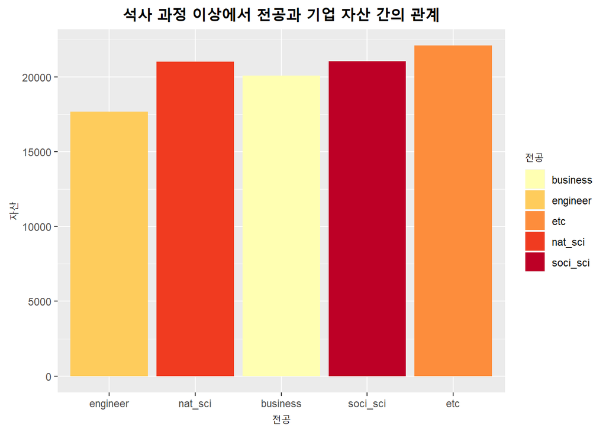

```r
graph3 <- gather_master %>%
  group_by(major) %>%
  summarise(mean_asset = mean(asset))

g2 <- ggplot(data = graph3, aes(x = major, y = mean_asset, fill = major)) +
  geom_col() +
  scale_fill_brewer(palette = 'YlOrRd') +
  scale_x_discrete(limits = c("engineer", "nat_sci", "business", "soci_sci", "etc")) +
  ggtitle("석사 과정 이상에서 전공과 기업 자산 간의 관계") +
  labs(fill = "전공") +
  theme(plot.title = element_text(family="NanumGothic", face="bold",size=15, hjust = 0.5)) +
  xlab('전공') +
  ylab('자산')
g2
```

```r
#시각화
```

먼저 전문학사/대졸 창업자의 전공은 모두 한 컬럼(u_master_major) 내에서 다른 숫자로 구분되어져 있어서 앞서 각각의 숫자에 맞는 전공명을 새로운 데이터프레임으로 만들어서 조인했다. 따라서 전문학사/대졸 창업자 전공을 구하는 것은 기존 데이터를 이용하면 되지만, 석사 이상 창업자의 전공은 한 컬럼에서 숫자로 나눠져있는게 아니라 전공이 각각의 컬럼으로 나눠져 있기 때문에 이를 하나의 컬럼(major)에 합치는 작업이 선행되어야 했다. 따라서 gather 함수를 이용한 후에 전공에 따른 자산을 계산할 수 있다.

결론적으로 석사 이상 창업자에게서는 기업 자산의 차이가 현저하게 나타나지 않지만, 대졸 및 전문과정에 있어서는 확연한 차이를 보이며, 자연과학, 경영, 공학 전공 순서의 창업자들의 기업자산이 더 높은 것으로 알 수 있다.

- 창업자의 창업 성공 및 실패경험과 기업 자산 간의 관계

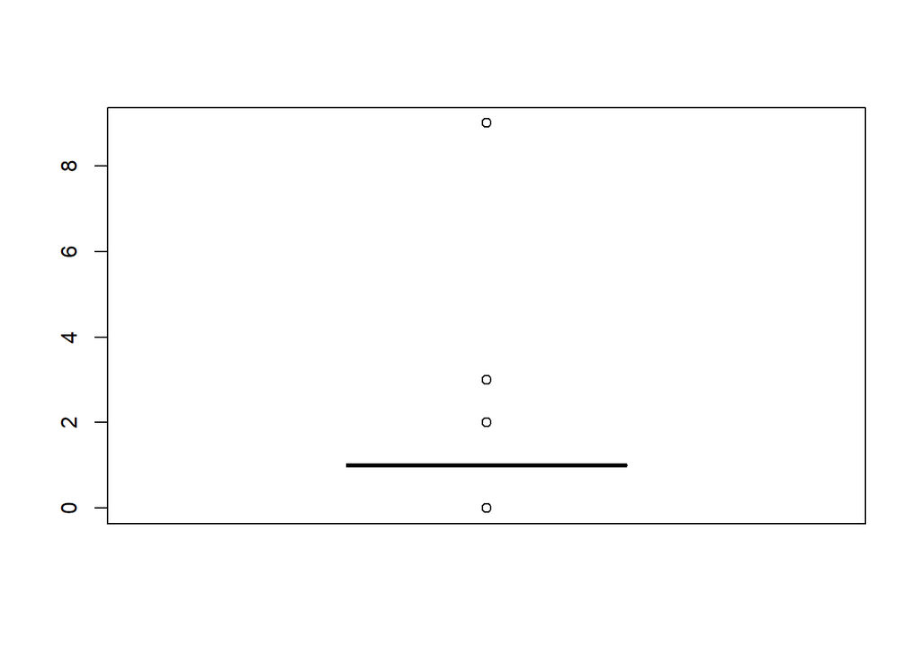

```
##      [,1]
## [1,]    1
## [2,]    1
## [3,]    1
## [4,]    1
## [5,]    1
```

```r
#성공 경험 및 실패 경험 변수의 outlier를 확인
boxplot(startup_tot$expr_success)
boxplot(startup_tot$expr_success)$stats
```

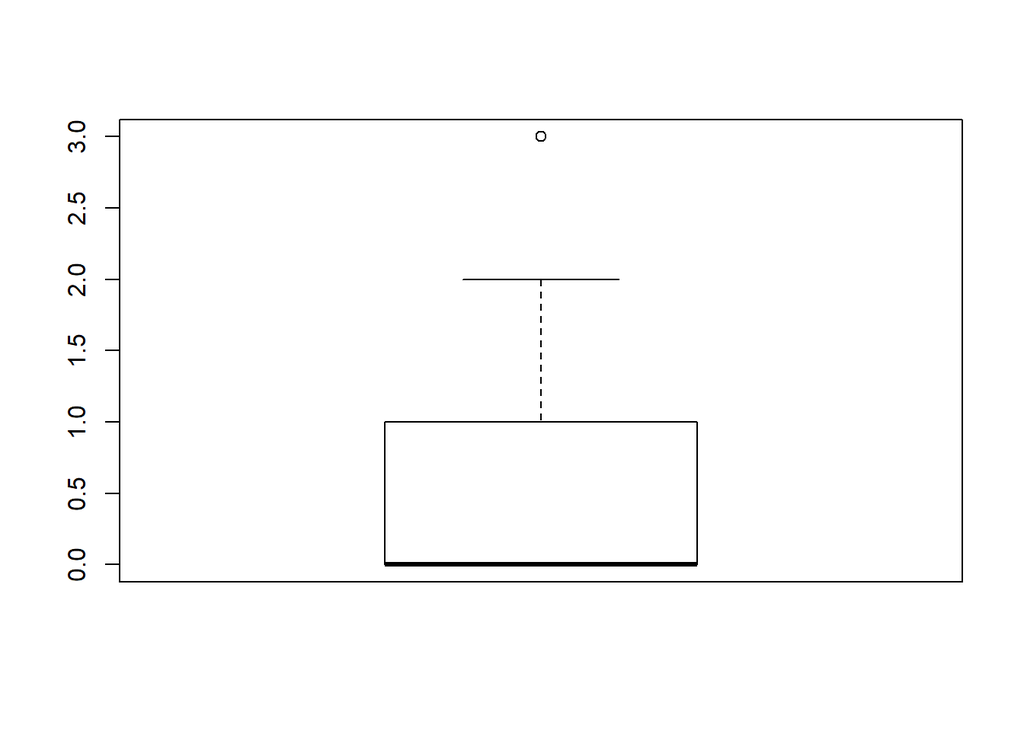

```
##      [,1]
## [1,]    0
## [2,]    0
## [3,]    0
## [4,]    1
## [5,]    2
```

```r
boxplot(startup_tot$expr_fail)
boxplot(startup_tot$expr_fail)$stats
```

```r
#극단치 제거
startup_tot$expr_success <- ifelse(startup_tot$expr_success == 9, NA, startup_tot$expr_success)
startup_tot <- startup_tot %>% filter(!is.na(expr_success))
table(startup_tot$expr_success)
```

```
##
##   0   1   2   3
##  59 183  28   7
```

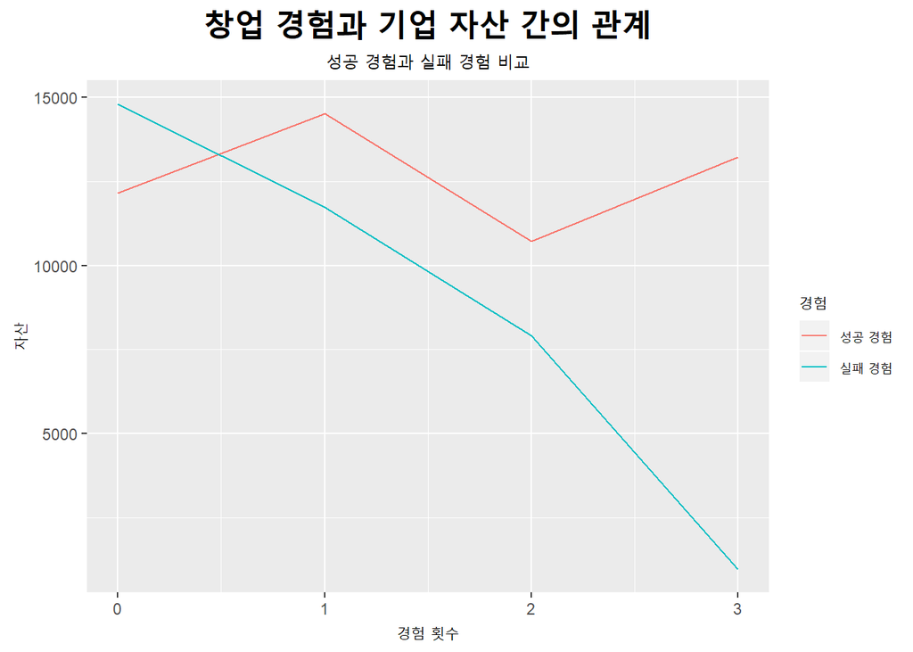

```r
#성공경험과 기업 자산 간의 관계
success <- startup_tot %>%
  filter(!is.na(expr_success)) %>%
  group_by(expr_success) %>%
  summarise(mean_asset = mean(asset))

#실패경험과 기업 자산 간의 관계
fail <- startup_tot %>%
  filter(!is.na(expr_fail)) %>%
  group_by(expr_fail) %>%
  summarise(mean_asset = mean(asset))

#시각화
g3 <- ggplot() +
  geom_line(data = success, aes(x=expr_success,y=mean_asset, col = "성공 경험")) +
  geom_line(data = fail, aes(x=expr_fail,y=mean_asset, col = "실패 경험")) +
  ggtitle("창업 경험과 기업 자산 간의 관계") +
  labs(col = "경험",
       subtitle = '성공 경험과 실패 경험 비교') +
  theme(plot.title = element_text(family="NanumGothic", face="bold",size=20, hjust = 0.5), plot.subtitle = element_text(family="NanumGothic",size=12, hjust = 0.5)) +
  xlab('경험 횟수') +
  ylab('자산')
g3
```

먼저 창업 성공 또는 실패 경험이 현재 기업을 제외한 과거의 창업 경험임을 명시한다. boxplot으로 극단치를 확인하는데 성공경험이 9인 경우를 극단치로 제외한 이유는 창업자의 현재 기업 창업 당시 나이를 묻는 문항(b2.3.-생략-)에서 해당 창업자는 2라고 적혀 있으므로 신뢰하지 못할 데이터일 가능성이 크기 때문이다.

그래프는 결과적으로 과거 창업에 대한 성공 경험과 실패 경험 모두 현재 기업 자산과 관계가 없는 것으로 나타난다. 오히려 실패 경험은 현재 기업의 자산과 반비례하는 모습을 나타나는데 납득하기 힘든 부분으로 보인다. 이에 대해서는 추가적인 분석이 필요할 것으로 요구된다.

> [추가분석]

추가적으로 몇몇 대학생들이 꿈꾸는 학생창업에 대한 부분을 분석해보았다. 주제는 ‘창업자의 전공 별 기업의 자산가치는 어느정도일까?’로 정하고 분석을 진행하였다. 여기에서 기업을 업력에 따라 3단계(3년이하기업, 4_5년기업, 기성기업)로 구분하였다. 그 이유는 일반적으로 기업이 업력이 4~5년에 접어들면 기업의 생산성과 규모가 하락하는 ’데스 밸리(죽음의 계곡)’ 구간으로 진입하는 것으로 알려져 있기 때문에 기업이 가진 이러한 기간의 특징을 반영하기 위해서이다.

```r
startup_tot %>%
  filter(years == "3년이하기업") %>%
  group_by(u_master_major) %>%
  summarise(mean_asset = mean(asset))
```

```
## # A tibble: 6 x 2
##   u_master_major mean_asset
##   <fct>               <dbl>
## 1 business            2278.
## 2 engineer             379.
## 3 etc                 2318.
## 4 nat_sci            16744.
## 5 soci_sci            2938.
## 6 <NA>                1257.
```

```r
startup_tot %>%
  filter(years == "4_5년기업") %>%
  group_by(u_master_major) %>%
  summarise(mean_asset = mean(asset))
```

```
## # A tibble: 6 x 2
##   u_master_major mean_asset
##   <fct>               <dbl>
## 1 business           15954.
## 2 engineer            2525
## 3 etc                  964.
## 4 nat_sci              980
## 5 soci_sci            2684.
## 6 <NA>                3963.
```

```r
startup_tot %>%
  filter(years == "기성기업") %>%
  group_by(u_master_major) %>%
  summarise(mean_asset = mean(asset))
```

```
## # A tibble: 6 x 2
##   u_master_major mean_asset
##   <fct>               <dbl>
## 1 business           18368.
## 2 engineer           17907.
## 3 etc                 2084
## 4 nat_sci            19181.
## 5 soci_sci           13191
## 6 <NA>               14667.
```

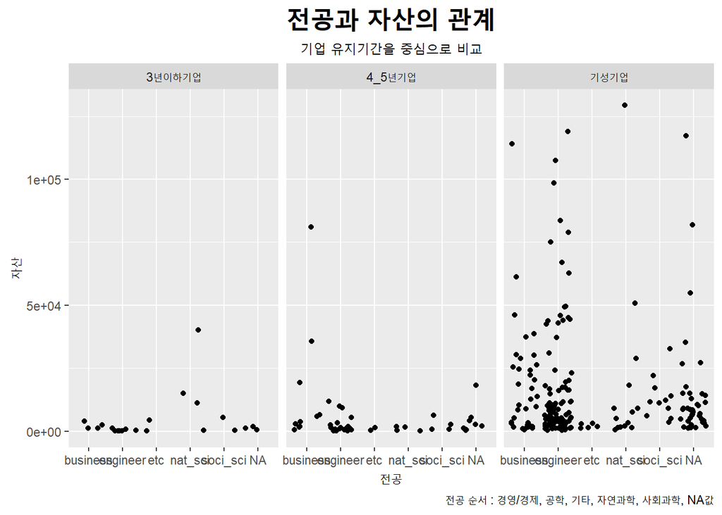

```r
g4 <- ggplot(startup_tot, aes(x=u_master_major, y=asset)) +
  geom_jitter() +
  facet_wrap( ~ years) +
  ggtitle("전공과 자산의 관계") +
  labs(subtitle = '기업 유지기간을 중심으로 비교',
       caption = '전공 순서 : 경영/경제, 공학, 기타, 자연과학, 사회과학, NA값') +
  theme(plot.title = element_text(family="NanumGothic", face="bold",size=20, hjust = 0.5), plot.subtitle = element_text(family="NanumGothic",size=12, hjust = 0.5)) +
  xlab('전공') +
  ylab('자산')
g4
```

그래프를 살펴보면 ’데스밸리’구간이 일반적으로 나타나지 않는 전공은 경영, 공학 분야인 것으로 나타난다. 흥미로운 부분은 공학을 전공한 대학생~대졸 창업자의 경우, 신생기업에서는 가장 낮은 평균자산을 보이지만, 기성기업으로 갈수록 평균자산이 큰 값으로 증가하는 높은 성장률을 보이는 것으로 확인할 수 있다.

#### 4. 최종 결과(시각화)

1. 창업자의 전공과 기업 자산 간의 관계

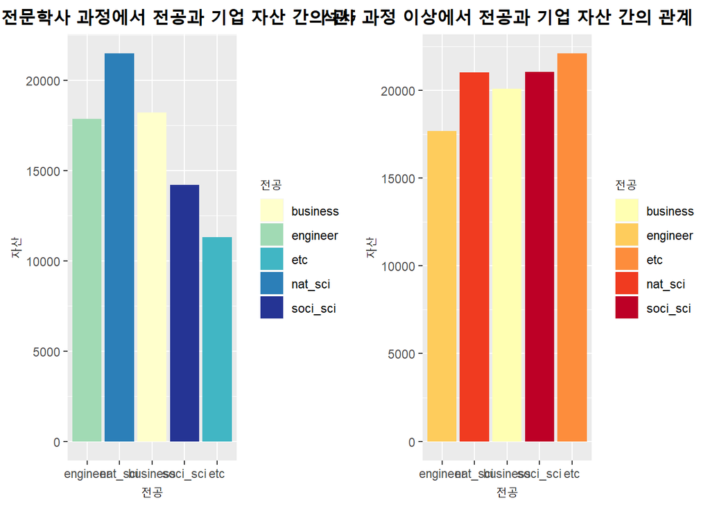

```r
grid.arrange(g1,g2, nrow=1, ncol=2)
```

**최종 결과 시각화라고 생각한다면 제목이나 x축-레이블 등이 겹치는 것도 신경을 써야 합니다. 그리고 색깔 범례는 x축에 표시가 되었기 때문에 굳이 필요하지 않습니다.**

2. 창업자의 창업 성공 및 실패경험과 기업 자산 간의 관계

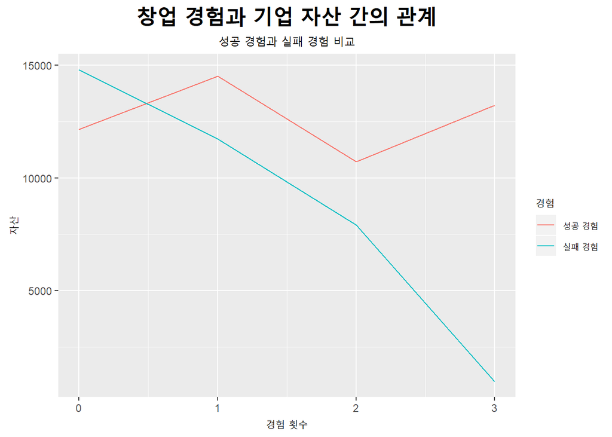

```r
g3
```

**평균만 그려놓으면 평균 차이의 유의미성을 알기 힘듭니다. 분포에 대해 이미 잘 알려져 있거나 특별히 평균만을 보여주려고 하는 것이 아니라면 산포도(scatterplot)를 그리거나 표준오차를 그리는 것이 좋습니다.**

예1)

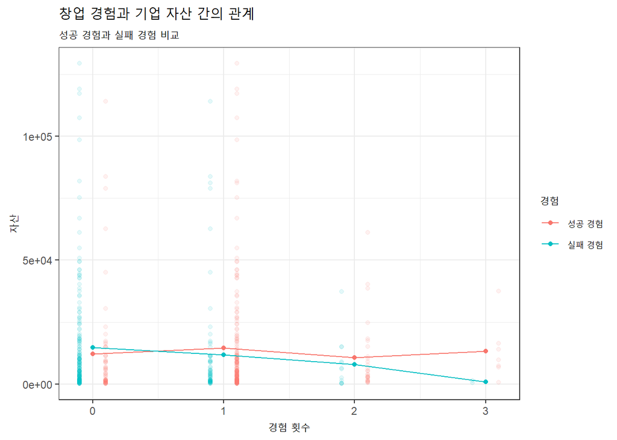

```r
library(ggplot2)
ggplot() +
  geom_point(data = startup_tot, aes(x=expr_success+0.1, y=asset, col = "성공 경험"),alpha=0.1) +
  geom_point(data = startup_tot, aes(x=expr_fail-0.1, y=asset, col = "실패 경험"), alpha=0.1) +
  geom_line(data = success, aes(x=expr_success,y=mean_asset, col = "성공 경험")) +
  geom_point(data = success, aes(x=expr_success,y=mean_asset, col = "성공 경험")) +
  geom_line(data = fail, aes(x=expr_fail,y=mean_asset, col = "실패 경험")) +
  geom_point(data = fail, aes(x=expr_fail,y=mean_asset, col = "실패 경험")) +
  ggtitle("창업 경험과 기업 자산 간의 관계") +
  labs(col = "경험",
       subtitle = '성공 경험과 실패 경험 비교') +
  theme(plot.title = element_text(family="NanumGothic", face="bold",size=20, hjust = 0.5), plot.subtitle = element_text(family="NanumGothic",size=12, hjust = 0.5)) +
  xlab('경험 횟수') +
  ylab('자산') + theme_bw()
```

**만약 y-축의 분포가 너무 넓다면 log10으로 변환(tranformation)할 수 있습니다.**

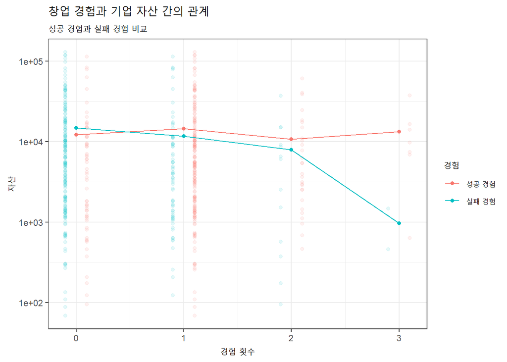

```r
library(ggplot2)
ggplot() +
  geom_point(data = startup_tot, aes(x=expr_success+0.1, y=asset, col = "성공 경험"),alpha=0.1) +
  geom_point(data = startup_tot, aes(x=expr_fail-0.1, y=asset, col = "실패 경험"), alpha=0.1) +
  geom_line(data = success, aes(x=expr_success,y=mean_asset, col = "성공 경험")) +
  geom_point(data = success, aes(x=expr_success,y=mean_asset, col = "성공 경험")) +
  geom_line(data = fail, aes(x=expr_fail,y=mean_asset, col = "실패 경험")) +
  geom_point(data = fail, aes(x=expr_fail,y=mean_asset, col = "실패 경험")) +
  ggtitle("창업 경험과 기업 자산 간의 관계") +
  labs(col = "경험",
       subtitle = '성공 경험과 실패 경험 비교') +
  theme(plot.title = element_text(family="NanumGothic", face="bold",size=20, hjust = 0.5), plot.subtitle = element_text(family="NanumGothic",size=12, hjust = 0.5)) +
  xlab('경험 횟수') +
  ylab('자산') + theme_bw()  + scale_y_log10()
```

**이 그래프를 보면 실패 경험이 3번인 회사는 2개 밖에 없기 때문에 작은표본(small sample) 문제가 있을 수 있음을 확인할 수 있습니다.**

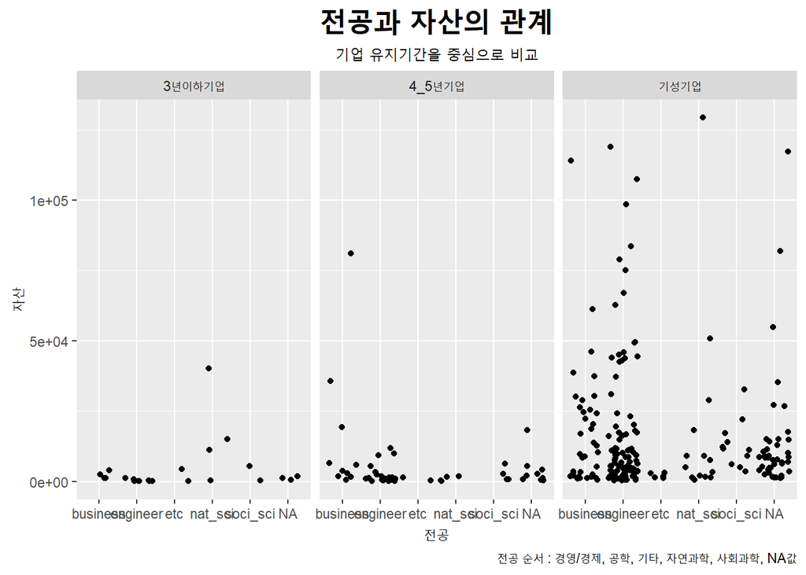

```r
g4
```